# DATA PREPERATION

## Import the dataset

```python
import pandas as pd

df=pd.read_csv("data.csv",low_memory=False)
```

## Provide your insight on the information and details that the provided dataset carries.

```python
df
```

|  | Unique Key | Created Date | Closed Date | Agency | Agency Name | Complaint Type | Descriptor | Location Type | Incident Zip | Incident Address | ... | Bridge Highway Name | Bridge Highway Direction | Road Ramp | Bridge Highway Segment | Garage Lot Name | Ferry Direction | Ferry Terminal Name | Latitude | Longitude | Location |
| --- | --- | --- | --- | --- | --- | --- | --- | --- | --- | --- | --- | --- | --- | --- | --- | --- | --- | --- | --- | --- | --- |
| 0 | 32310363 | 12/31/2015 11:59:45 PM | 01-01-16 0:55 | NYPD | New York City Police Department | Noise - Street/Sidewalk | Loud Music/Party | Street/Sidewalk | 10034.0 | 71 VERMILYEA AVENUE | ... | NaN | NaN | NaN | NaN | NaN | NaN | NaN | 40.865682 | -73.923501 | (40.86568153633767, -73.92350095571744) |
| 1 | 32309934 | 12/31/2015 11:59:44 PM | 01-01-16 1:26 | NYPD | New York City Police Department | Blocked Driveway | No Access | Street/Sidewalk | 11105.0 | 27-07 23 AVENUE | ... | NaN | NaN | NaN | NaN | NaN | NaN | NaN | 40.775945 | -73.915094 | (40.775945312321085, -73.91509393898605) |
| 2 | 32309159 | 12/31/2015 11:59:29 PM | 01-01-16 4:51 | NYPD | New York City Police Department | Blocked Driveway | No Access | Street/Sidewalk | 10458.0 | 2897 VALENTINE AVENUE | ... | NaN | NaN | NaN | NaN | NaN | NaN | NaN | 40.870325 | -73.888525 | (40.870324522111424, -73.88852464418646) |
| 3 | 32305098 | 12/31/2015 11:57:46 PM | 01-01-16 7:43 | NYPD | New York City Police Department | Illegal Parking | Commercial Overnight Parking | Street/Sidewalk | 10461.0 | 2940 BAISLEY AVENUE | ... | NaN | NaN | NaN | NaN | NaN | NaN | NaN | 40.835994 | -73.828379 | (40.83599404683083, -73.82837939584206) |
| 4 | 32306529 | 12/31/2015 11:56:58 PM | 01-01-16 3:24 | NYPD | New York City Police Department | Illegal Parking | Blocked Sidewalk | Street/Sidewalk | 11373.0 | 87-14 57 ROAD | ... | NaN | NaN | NaN | NaN | NaN | NaN | NaN | 40.733060 | -73.874170 | (40.733059618956815, -73.87416975810375) |
| ... | ... | ... | ... | ... | ... | ... | ... | ... | ... | ... | ... | ... | ... | ... | ... | ... | ... | ... | ... | ... | ... |
| 300693 | 30281872 | 03/29/2015 12:33:41 AM | NaN | NYPD | New York City Police Department | Noise - Commercial | Loud Music/Party | Club/Bar/Restaurant | NaN | CRESCENT AVENUE | ... | NaN | NaN | NaN | NaN | NaN | NaN | NaN | NaN | NaN | NaN |
| 300694 | 30281230 | 03/29/2015 12:33:28 AM | 03/29/2015 02:33:59 AM | NYPD | New York City Police Department | Blocked Driveway | Partial Access | Street/Sidewalk | 11418.0 | 100-17 87 AVENUE | ... | NaN | NaN | NaN | NaN | NaN | NaN | NaN | 40.694077 | -73.846087 | (40.69407728322387, -73.8460866160573) |
| 300695 | 30283424 | 03/29/2015 12:33:03 AM | 03/29/2015 03:40:20 AM | NYPD | New York City Police Department | Noise - Commercial | Loud Music/Party | Club/Bar/Restaurant | 11206.0 | 162 THROOP AVENUE | ... | NaN | NaN | NaN | NaN | NaN | NaN | NaN | 40.699590 | -73.944234 | (40.69959035300927, -73.94423377144169) |
| 300696 | 30280004 | 03/29/2015 12:33:02 AM | 03/29/2015 04:38:35 AM | NYPD | New York City Police Department | Noise - Commercial | Loud Music/Party | Club/Bar/Restaurant | 10461.0 | 3151 EAST TREMONT AVENUE | ... | NaN | NaN | NaN | NaN | NaN | NaN | NaN | 40.837708 | -73.834587 | (40.8377075854206, -73.83458731019586) |
| 300697 | 30281825 | 03/29/2015 12:33:01 AM | 03/29/2015 04:41:50 AM | NYPD | New York City Police Department | Noise - Commercial | Loud Music/Party | Store/Commercial | 10036.0 | 251 WEST 48 STREET | ... | NaN | NaN | NaN | NaN | NaN | NaN | NaN | 40.760583 | -73.985922 | (40.76058322950115, -73.98592204392392) |

300698 rows × 53 columns

```python
df.info()
```

```
<class 'pandas.core.frame.DataFrame'>
RangeIndex: 300698 entries, 0 to 300697
Data columns (total 53 columns):
 #   Column                          Non-Null Count   Dtype
---  ------                          --------------   -----
 0   Unique Key                      300698 non-null  int64
 1   Created Date                    300698 non-null  object
 2   Closed Date                     298534 non-null  object
 3   Agency                          300698 non-null  object
 4   Agency Name                     300698 non-null  object
 5   Complaint Type                  300698 non-null  object
 6   Descriptor                      294784 non-null  object
 7   Location Type                   300567 non-null  object
 8   Incident Zip                    298083 non-null  float64
 9   Incident Address                256288 non-null  object
```

[output cut: 45 more lines]

```python
df.describe(include="all")
```

|  | Unique Key | Created Date | Closed Date | Agency | Agency Name | Complaint Type | Descriptor | Location Type | Incident Zip | Incident Address | ... | Bridge Highway Name | Bridge Highway Direction | Road Ramp | Bridge Highway Segment | Garage Lot Name | Ferry Direction | Ferry Terminal Name | Latitude | Longitude | Location |
| --- | --- | --- | --- | --- | --- | --- | --- | --- | --- | --- | --- | --- | --- | --- | --- | --- | --- | --- | --- | --- | --- |
| count | 3.006980e+05 | 300698 | 298534 | 300698 | 300698 | 300698 | 294784 | 300567 | 298083.000000 | 256288 | ... | 243 | 243 | 213 | 213 | 0.0 | 1 | 2 | 297158.000000 | 297158.000000 | 297158 |
| unique | NaN | 259493 | 237165 | 1 | 3 | 24 | 45 | 18 | NaN | 107652 | ... | 29 | 34 | 2 | 160 | NaN | 1 | 2 | NaN | NaN | 126048 |
| top | NaN | 07-11-15 23:04 | 11-08-15 7:34 | NYPD | New York City Police Department | Blocked Driveway | Loud Music/Party | Street/Sidewalk | NaN | 1207 BEACH AVENUE | ... | FDR Dr | East/Queens Bound | Roadway | East 96th St (Exit 14) - Triborough Br (Exit 17) | NaN | Manhattan Bound | St. George Terminal (Staten Island) | NaN | NaN | (40.83036235589997, -73.86602154214397) |
| freq | NaN | 9 | 24 | 300698 | 300690 | 77044 | 61430 | 249299 | NaN | 904 | ... | 33 | 21 | 162 | 6 | NaN | 1 | 1 | NaN | NaN | 902 |
| mean | 3.130054e+07 | NaN | NaN | NaN | NaN | NaN | NaN | NaN | 10848.888645 | NaN | ... | NaN | NaN | NaN | NaN | NaN | NaN | NaN | 40.725885 | -73.925630 | NaN |
| std | 5.738547e+05 | NaN | NaN | NaN | NaN | NaN | NaN | NaN | 583.182081 | NaN | ... | NaN | NaN | NaN | NaN | NaN | NaN | NaN | 0.082012 | 0.078454 | NaN |
| min | 3.027948e+07 | NaN | NaN | NaN | NaN | NaN | NaN | NaN | 83.000000 | NaN | ... | NaN | NaN | NaN | NaN | NaN | NaN | NaN | 40.499135 | -74.254937 | NaN |
| 25% | 3.080118e+07 | NaN | NaN | NaN | NaN | NaN | NaN | NaN | 10310.000000 | NaN | ... | NaN | NaN | NaN | NaN | NaN | NaN | NaN | 40.669796 | -73.972142 | NaN |
| 50% | 3.130436e+07 | NaN | NaN | NaN | NaN | NaN | NaN | NaN | 11208.000000 | NaN | ... | NaN | NaN | NaN | NaN | NaN | NaN | NaN | 40.718661 | -73.931781 | NaN |
| 75% | 3.178446e+07 | NaN | NaN | NaN | NaN | NaN | NaN | NaN | 11238.000000 | NaN | ... | NaN | NaN | NaN | NaN | NaN | NaN | NaN | 40.781840 | -73.876805 | NaN |
| max | 3.231065e+07 | NaN | NaN | NaN | NaN | NaN | NaN | NaN | 11697.000000 | NaN | ... | NaN | NaN | NaN | NaN | NaN | NaN | NaN | 40.912869 | -73.700760 | NaN |

11 rows × 53 columns

```python
df.dtypes
```

```
Unique Key                          int64
Created Date                       object
Closed Date                        object
Agency                             object
Agency Name                        object
Complaint Type                     object
Descriptor                         object
Location Type                      object
Incident Zip                      float64
Incident Address                   object
Street Name                        object
Cross Street 1                     object
Cross Street 2                     object
Intersection Street 1              object
Intersection Street 2              object
Address Type                       object
City                               object
Landmark                           object
Facility Type                      object
Status                             object
Due Date                           object
Resolution Description             object
Resolution Action Updated Date     object
Community Board                    object
Borough                            object
X Coordinate (State Plane)        float64
Y Coordinate (State Plane)        float64
Park Facility Name                 object
Park Borough                       object
School Name                        object
School Number                      object
School Region                      object
School Code                        object
School Phone Number                object
School Address                     object
School City                        object
School State                       object
School Zip                         object
School Not Found                   object
School or Citywide Complaint      float64
Vehicle Type                      float64
Taxi Company Borough              float64
Taxi Pick Up Location             float64
Bridge Highway Name                object
Bridge Highway Direction           object
Road Ramp                          object
Bridge Highway Segment             object
Garage Lot Name                   float64
Ferry Direction                    object
Ferry Terminal Name                object
Latitude                          float64
Longitude                         float64
Location                           object
dtype: object
```

## Convert the columns "Created Date" and "Closed Date" to datetime datatype and create a new column "Request_Closing_Time" as the time elapsed between request creation and request closing

```python
df["Created Date"]=pd.to_datetime(df["Created Date"],format="mixed")
```

```python
df["Closed Date"]=pd.to_datetime(df["Closed Date"],format="mixed")
```

```python
df["Request_Closing_Time"] = df["Closed Date"] - df["Created Date"]
```

```python
# To check the changed datatype of Created Date and Closed Date and the formation of new column Request Closing Time.
print(df.dtypes)
```

```
Unique Key                                  int64
Created Date                       datetime64[ns]
Closed Date                        datetime64[ns]
Agency                                     object
Agency Name                                object
Complaint Type                             object
Descriptor                                 object
Location Type                              object
Incident Zip                              float64
Incident Address                           object
Street Name                                object
Cross Street 1                             object
Cross Street 2                             object
Intersection Street 1                      object
Intersection Street 2                      object
Address Type                               object
City                                       object
Landmark                                   object
Facility Type                              object
Status                                     object
Due Date                                   object
Resolution Description                     object
Resolution Action Updated Date             object
Community Board                            object
Borough                                    object
X Coordinate (State Plane)                float64
Y Coordinate (State Plane)                float64
Park Facility Name                         object
Park Borough                               object
School Name                                object
School Number                              object
School Region                              object
School Code                                object
School Phone Number                        object
School Address                             object
School City                                object
School State                               object
School Zip                                 object
School Not Found                           object
School or Citywide Complaint              float64
Vehicle Type                              float64
Taxi Company Borough                      float64
Taxi Pick Up Location                     float64
Bridge Highway Name                        object
Bridge Highway Direction                   object
Road Ramp                                  object
Bridge Highway Segment                     object
Garage Lot Name                           float64
Ferry Direction                            object
Ferry Terminal Name                        object
Latitude                                  float64
Longitude                                 float64
Location                                   object
Request_Closing_Time              timedelta64[ns]
dtype: object
```

## Write a Python program to drop irrelevant columns which are listed below.

#### ['Agency Name', 'Incident Address', 'Street Name', 'Cross Street 1', 'Cross Street 2', 'Intersection Street 1', 'Intersection Street 2', 'Address Type', 'Park Facility Name', 'Park Borough', 'School Name', 'School Number', 'School Region', 'School Code', 'School Phone Number', 'School Address', 'School City', 'School State', 'School Zip', 'School Not Found', 'School or Citywide Complaint', 'Vehicle Type', 'Taxi Company Borough', 'Taxi Pick Up Location', 'Bridge Highway Name', 'Bridge Highway Direction', 'Road Ramp', 'Bridge Highway Segment', 'Garage Lot Name', 'Ferry Direction', 'Ferry Terminal Name', 'Landmark', 'X Coordinate (State Plane)', 'Y Coordinate (State Plane)', 'Due Date', 'Resolution Action Updated Date', 'Community Board', 'Facility Type', 'Location']

```python
df=df.drop([
    'Agency Name','Incident Address','Street Name','Cross Street 1','Cross Street 2',
    'Intersection Street 1', 'Intersection Street 2','Address Type','Park Facility Name',
    'Park Borough','School Name', 'School Number','School Region','School Code',
    'School Phone Number','School Address','School City','School State','School Zip',
    'School Not Found','School or Citywide Complaint','Vehicle Type', 'Taxi Company Borough',
    'Taxi Pick Up Location','Bridge Highway Name','Bridge Highway Direction','Road Ramp',
    'Bridge Highway Segment','Garage Lot Name','Ferry Direction','Ferry Terminal Name',
    'Landmark','X Coordinate (State Plane)','Y Coordinate (State Plane)','Due Date',
    'Resolution Action Updated Date','Community Board','Facility Type','Location'],axis="columns")
```

```python
#printing to check the removal of above mentioned columns
print(df.dtypes)
```

```
Unique Key                          int64
Created Date               datetime64[ns]
Closed Date                datetime64[ns]
Agency                             object
Complaint Type                     object
Descriptor                         object
Location Type                      object
Incident Zip                      float64
City                               object
Status                             object
Resolution Description             object
Borough                            object
Latitude                          float64
Longitude                         float64
Request_Closing_Time      timedelta64[ns]
dtype: object
```

## Write a python program to remove the NaN missing values from updated dataframe.

```python
df.dropna(inplace=True)
```

```python
#checing the values to see if NaN values exist
df
```

|  | Unique Key | Created Date | Closed Date | Agency | Complaint Type | Descriptor | Location Type | Incident Zip | City | Status | Resolution Description | Borough | Latitude | Longitude | Request_Closing_Time |
| --- | --- | --- | --- | --- | --- | --- | --- | --- | --- | --- | --- | --- | --- | --- | --- |
| 0 | 32310363 | 2015-12-31 23:59:45 | 2016-01-01 00:55:00 | NYPD | Noise - Street/Sidewalk | Loud Music/Party | Street/Sidewalk | 10034.0 | NEW YORK | Closed | The Police Department responded and upon arriv... | MANHATTAN | 40.865682 | -73.923501 | 0 days 00:55:15 |
| 1 | 32309934 | 2015-12-31 23:59:44 | 2016-01-01 01:26:00 | NYPD | Blocked Driveway | No Access | Street/Sidewalk | 11105.0 | ASTORIA | Closed | The Police Department responded to the complai... | QUEENS | 40.775945 | -73.915094 | 0 days 01:26:16 |
| 2 | 32309159 | 2015-12-31 23:59:29 | 2016-01-01 04:51:00 | NYPD | Blocked Driveway | No Access | Street/Sidewalk | 10458.0 | BRONX | Closed | The Police Department responded and upon arriv... | BRONX | 40.870325 | -73.888525 | 0 days 04:51:31 |
| 3 | 32305098 | 2015-12-31 23:57:46 | 2016-01-01 07:43:00 | NYPD | Illegal Parking | Commercial Overnight Parking | Street/Sidewalk | 10461.0 | BRONX | Closed | The Police Department responded to the complai... | BRONX | 40.835994 | -73.828379 | 0 days 07:45:14 |
| 4 | 32306529 | 2015-12-31 23:56:58 | 2016-01-01 03:24:00 | NYPD | Illegal Parking | Blocked Sidewalk | Street/Sidewalk | 11373.0 | ELMHURST | Closed | The Police Department responded and upon arriv... | QUEENS | 40.733060 | -73.874170 | 0 days 03:27:02 |
| ... | ... | ... | ... | ... | ... | ... | ... | ... | ... | ... | ... | ... | ... | ... | ... |
| 300692 | 30281370 | 2015-03-29 00:34:32 | 2015-03-29 01:13:01 | NYPD | Noise - Commercial | Loud Music/Party | Store/Commercial | 10002.0 | NEW YORK | Closed | The Police Department responded to the complai... | MANHATTAN | 40.716053 | -73.991378 | 0 days 00:38:29 |
| 300694 | 30281230 | 2015-03-29 00:33:28 | 2015-03-29 02:33:59 | NYPD | Blocked Driveway | Partial Access | Street/Sidewalk | 11418.0 | RICHMOND HILL | Closed | The Police Department responded and upon arriv... | QUEENS | 40.694077 | -73.846087 | 0 days 02:00:31 |
| 300695 | 30283424 | 2015-03-29 00:33:03 | 2015-03-29 03:40:20 | NYPD | Noise - Commercial | Loud Music/Party | Club/Bar/Restaurant | 11206.0 | BROOKLYN | Closed | The Police Department responded to the complai... | BROOKLYN | 40.699590 | -73.944234 | 0 days 03:07:17 |
| 300696 | 30280004 | 2015-03-29 00:33:02 | 2015-03-29 04:38:35 | NYPD | Noise - Commercial | Loud Music/Party | Club/Bar/Restaurant | 10461.0 | BRONX | Closed | The Police Department responded to the complai... | BRONX | 40.837708 | -73.834587 | 0 days 04:05:33 |
| 300697 | 30281825 | 2015-03-29 00:33:01 | 2015-03-29 04:41:50 | NYPD | Noise - Commercial | Loud Music/Party | Store/Commercial | 10036.0 | NEW YORK | Closed | The Police Department responded to the complai... | MANHATTAN | 40.760583 | -73.985922 | 0 days 04:08:49 |

291107 rows × 15 columns

## Write a python program to see the unique values from all the columns in the dataframe

```python
for col in df.columns:
    print(df[col].unique())
```

```
[32310363 32309934 32309159 ... 30283424 30280004 30281825]
<DatetimeArray>
['2015-12-31 23:59:45', '2015-12-31 23:59:44', '2015-12-31 23:59:29',
 '2015-12-31 23:57:46', '2015-12-31 23:56:58', '2015-12-31 23:56:30',
 '2015-12-31 23:55:32', '2015-12-31 23:54:05', '2015-12-31 23:53:58',
 '2015-12-31 23:52:58',
 ...
 '2015-03-29 00:42:48', '2015-03-29 00:37:15', '2015-03-29 00:35:28',
 '2015-03-29 00:35:23', '2015-03-29 00:35:04', '2015-03-29 00:34:32',
 '2015-03-29 00:33:28', '2015-03-29 00:33:03', '2015-03-29 00:33:02',
 '2015-03-29 00:33:01']
Length: 251970, dtype: datetime64[ns]
<DatetimeArray>
['2016-01-01 00:55:00', '2016-01-01 01:26:00', '2016-01-01 04:51:00',
 '2016-01-01 07:43:00', '2016-01-01 03:24:00', '2016-01-01 01:50:00',
 '2016-01-01 01:53:00', '2016-01-01 01:42:00', '2016-01-01 08:27:00',
 '2016-01-01 01:17:00',
 ...
 '2015-03-29 00:57:23', '2015-03-29 02:57:41', '2015-03-29 01:02:39',
 '2015-03-29 04:14:27', '2015-03-29 08:41:24', '2015-03-29 02:52:28',
 '2015-03-29 01:13:01', '2015-03-29 02:33:59', '2015-03-29 04:38:35',
 '2015-03-29 04:41:50']
Length: 231991, dtype: datetime64[ns]
['NYPD']
['Noise - Street/Sidewalk' 'Blocked Driveway' 'Illegal Parking'
 'Derelict Vehicle' 'Noise - Commercial' 'Noise - House of Worship'
 'Posting Advertisement' 'Noise - Vehicle' 'Animal Abuse' 'Vending'
 'Traffic' 'Drinking' 'Noise - Park' 'Graffiti' 'Disorderly Youth']
['Loud Music/Party' 'No Access' 'Commercial Overnight Parking'
 'Blocked Sidewalk' 'Posted Parking Sign Violation' 'Blocked Hydrant'
 'With License Plate' 'Partial Access' 'Unauthorized Bus Layover'
 'Double Parked Blocking Vehicle' 'Vehicle' 'Loud Talking'
 'Banging/Pounding' 'Car/Truck Music' 'Tortured' 'In Prohibited Area'
 'Double Parked Blocking Traffic' 'Congestion/Gridlock' 'Neglected'
 'Car/Truck Horn' 'In Public' 'Other (complaint details)' 'No Shelter'
 'Truck Route Violation' 'Unlicensed' 'Overnight Commercial Storage'
 'Engine Idling' 'After Hours - Licensed Est' 'Detached Trailer'
 'Underage - Licensed Est' 'Chronic Stoplight Violation' 'Loud Television'
 'Chained' 'Building' 'In Car' 'Police Report Requested'
 'Chronic Speeding' 'Playing in Unsuitable Place' 'Drag Racing'
```

[output cut: 48 more lines]

```
 "Your complaint has been forwarded to the New York Police Department for a non-emergency response. If the police determine the vehicle is illegally parked, they will ticket the vehicle and then you may either contact a private towing company to remove the vehicle or ask your local precinct to conta…
['MANHATTAN' 'QUEENS' 'BRONX' 'BROOKLYN' 'STATEN ISLAND']
[40.86568154 40.77594531 40.87032452 ... 40.77664592 40.70635259
 40.71605291]
[-73.92350096 -73.91509394 -73.88852464 ... -73.94880526 -73.87124456
 -73.9913785 ]
<TimedeltaArray>
['0 days 00:55:15', '0 days 01:26:16', '0 days 04:51:31', '0 days 07:45:14',
 '0 days 03:27:02', '0 days 01:53:30', '0 days 01:57:28', '0 days 01:47:55',
 '0 days 08:33:02', '0 days 01:23:02',
 ...
 '0 days 06:46:59', '0 days 07:28:23', '0 days 05:13:46', '0 days 05:19:11',
 '0 days 10:22:47', '0 days 09:46:41', '0 days 15:40:46', '0 days 04:44:52',
 '0 days 09:44:44', '0 days 15:42:26']
Length: 47134, dtype: timedelta64[ns]
```

## Write a Python program to show summary statistics of Sum, Mean, Standard deviation, Skewness, and Kurtosis of the data frame.

```python
import statistics
```

```python
print(df.sum(numeric_only=True))
```

```
Unique Key      9.112108e+12
Incident Zip    3.160833e+09
Latitude        1.185553e+07
Longitude      -2.152010e+07
dtype: float64
```

```python
print(df.mean(numeric_only=True))
```

```
Unique Key      3.130158e+07
Incident Zip    1.085798e+04
Latitude        4.072568e+01
Longitude      -7.392504e+01
dtype: float64
```

```python
print(df.std(numeric_only=True))
```

```
Unique Key      575377.738707
Incident Zip       580.280774
Latitude             0.082411
Longitude            0.078654
dtype: float64
```

```python
print(df.skew(numeric_only=True))
```

```
Unique Key      0.016898
Incident Zip   -2.553956
Latitude        0.123114
Longitude      -0.312739
dtype: float64
```

```python
print(df.kurtosis(numeric_only=True))
```

```
Unique Key      -1.176593
Incident Zip    37.827777
Latitude        -0.734818
Longitude        1.455600
dtype: float64
```

## Write a Python program to calculate and show correlation of all variables.

```python
print(df.corr(numeric_only=True))
```

```
              Unique Key  Incident Zip  Latitude  Longitude
Unique Key      1.000000      0.025492 -0.032613  -0.008621
Incident Zip    0.025492      1.000000 -0.499081   0.385934
Latitude       -0.032613     -0.499081  1.000000   0.368819
Longitude      -0.008621      0.385934  0.368819   1.000000
```

## Provide four major insights through visualization that you come up after data mining.

```python
import matplotlib.pyplot as plt
```

#### Sorting the number of complaints by type to find the frequency of complaints.

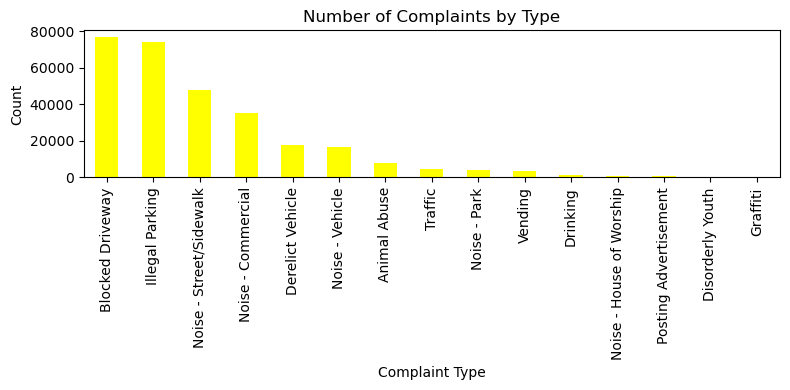

```python
# Count complaints by type and plot as a bar chart

counts = df['Complaint Type'].value_counts().sort_values(ascending=False)
counts.plot(kind='bar', color='yellow', figsize=(8,4))
plt.title("Number of Complaints by Type")
plt.xlabel("Complaint Type")
plt.ylabel("Count")
plt.tight_layout()
plt.show()
```

#### Counting the number of complaints by borough to find the difference between the frequency of complaints from different boroughs

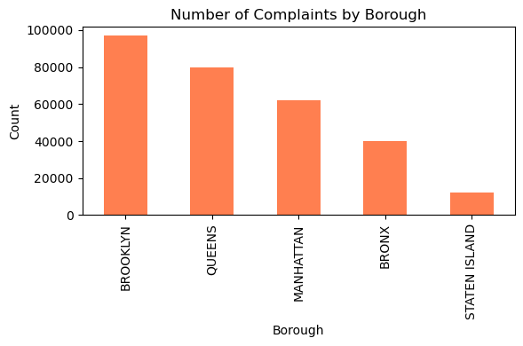

```python
# Count complaints by borough and plot as a bar chart

borough_counts = df['Borough'].value_counts()
borough_counts.plot(kind='bar', color='coral', figsize=(6,4))
plt.title("Number of Complaints by Borough")
plt.xlabel("Borough")
plt.ylabel("Count")
plt.tight_layout()
plt.show()
```

#### Computing average closing time in days by complaint type to find the average time it takes for a certain complaint to be solved.

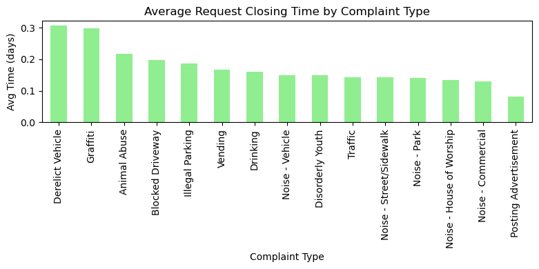

```python
df['Request_Closing_Time_Days'] = df['Request_Closing_Time'].dt.total_seconds() / (24*3600)
avg_time = df.groupby('Complaint Type')['Request_Closing_Time_Days'].mean().sort_values(ascending=False)
avg_time.plot(kind='bar', color='lightgreen', figsize=(8,4))
plt.title("Average Request Closing Time by Complaint Type")
plt.xlabel("Complaint Type")
plt.ylabel("Avg Time (days)")
plt.tight_layout()
plt.show()
```

#### Plotting the Number of Complaints over time to find the variation of complaints through a year.

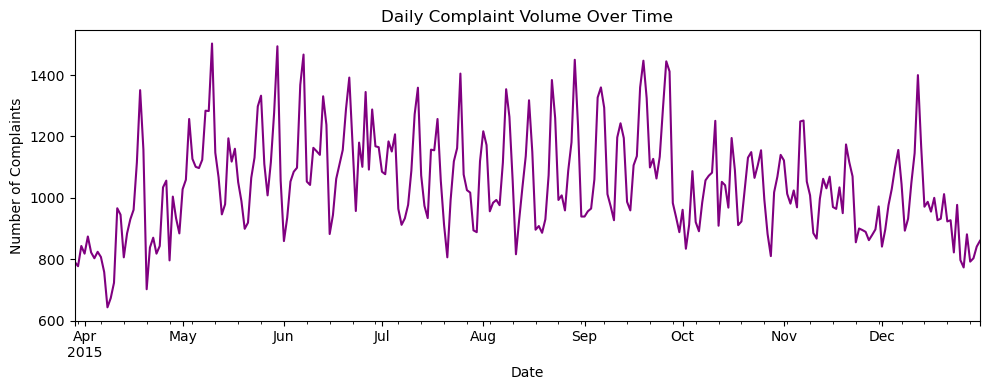

```python
daily_complaints = df.set_index('Created Date').resample('D').size()

# Plotting
plt.figure(figsize=(10, 4))
daily_complaints.plot(color='purple')
plt.title("Daily Complaint Volume Over Time")
plt.xlabel("Date")
plt.ylabel("Number of Complaints")
plt.tight_layout()
plt.show()
```

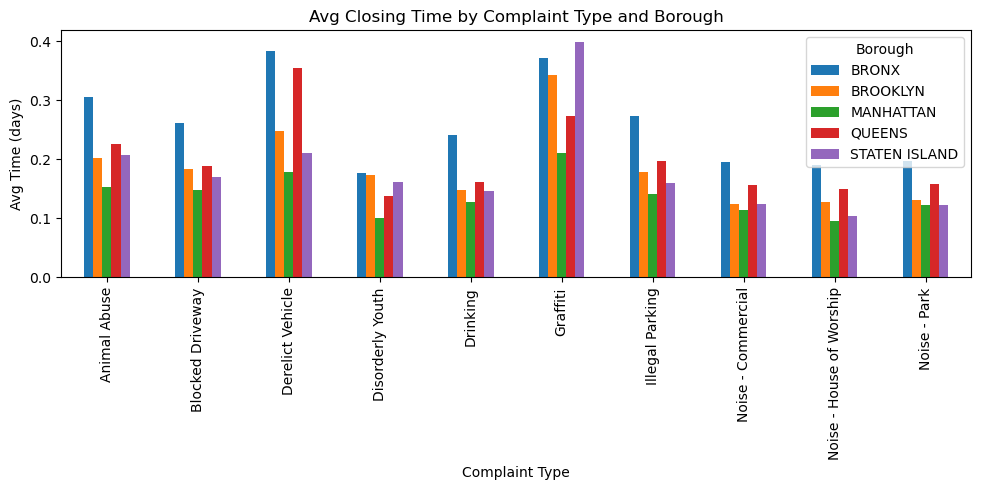

```python
# Compute pivot: average closing time by complaint type and borough
pivot = df.groupby(['Complaint Type','Borough'])['Request_Closing_Time_Days'].mean().unstack().head(10)
pivot.plot(kind='bar', figsize=(10,5))
plt.title("Avg Closing Time by Complaint Type and Borough")
plt.xlabel("Complaint Type")
plt.ylabel("Avg Time (days)")
plt.legend(title="Borough")
plt.tight_layout()
plt.show()
```

# Statistical Testing

### Test 1: Whether the average response time across complaint types is similaror not.

### ● State the Null Hypothesis (H0) and Alternate Hypothesis (H1).

### ● Perform the statistical test and provide the p-value.

### ● Interpret the results to accept or reject the Null Hypothesis

H₀ (Null Hypothesis): The mean response time is the same across all complaint types. (μ₁ = μ₂ = μ₃ = ... = μₙ) H₁ (Alternative Hypothesis): At least one complaint type has a mean response time different from the others. (∃ i, j such that μᵢ ≠ μⱼ)

```python
from scipy import stats

# Prepare list of arrays of closing times for each complaint type
groups = [grp['Request_Closing_Time_Days'].values
          for _, grp in df.groupby('Complaint Type')]

F_stat, p_val = stats.f_oneway(*groups)

print(f"ANOVA Results:\nF-statistic = {F_stat:.3f}, p-value = {p_val:.4f}\n")

if p_val<0.05:
    print("We reject the null hypothesis")
    print("There is a significant difference in average response time across complaint types.")
else:
    print("we accept the null hypothesis")
    print("No significant difference in average response time across complaint types.")
```

```
ANOVA Results:
F-statistic = 578.912, p-value = 0.0000

We reject the null hypothesis
There is a significant difference in average response time across complaint types.
```

## Test 2: Whether the type of complaint or service requested and location arerelated.

## ● State the Null Hypothesis (H0) and Alternate Hypothesis (H1).

## ● Perform the statistical test and provide the p-value.

## ● Interpret the results to accept or reject the Null Hypothesis

H0(Null Hypothesis): Complaint type and borough are independent (no association). H1(Alternate Hypothesis): Complaint type and borough are related (not independent).

```python
# Build contingency table
contingency = pd.crosstab(df['Complaint Type'], df['Borough'])

chi2, p_val, dof, expected = stats.chi2_contingency(contingency)

print(f"Chi-squared test: chi2 ={ chi2}, p ={p_val}\n")


if p_val<0.05:
    print("We reject the null hypothesis")
    print("The complaint type and borough are dependent on each other")

else:
    print("we accept the null hypothesis")
    print("THe complaint type and borough are independent of each other")
```

```
Chi-squared test: chi2 =73264.62164334783, p =0.0

We reject the null hypothesis
The complaint type and borough are dependent on each other
```